# Project Data Set

Xinyue Chen

2022-10-23

# 1 Introduction of NACC

NACC is the abbreviation of National Alzheimer’s Coordinating Center. It’s a data set I can access to for my RA’s project. All the information about this data set was copied from the *NACC Uniform Data Set – Researchers Data Dictionary.* The data were collected from various Alzheimer’s Disease Research Centers across the United States. A total of 34542 participants were recruited to participate in this cohort study.

## 1.1 Load data set

My project focuses on the correlation between Atrial Fibrillation (AF) and cognitive status. AF is an irregular, often rapid, abnormal heart rhythm that decreases cardiac output by 25-33% and currently affects over 6 million people in the U.S. AF occurs in 10% of adults over 70 years of age and 20% of patients over 80. It is believed that once AF is detected, the condition never goes away. AF has been shown to be an independent risk factor for serious consequences of stroke, heart failure, and may contribute to decline in cognition function over time, leading to mild cognitive impairment (MCI) and dementia.

# 2 Descriptive analysis

## 2.1 Summary of Baseline Data

### 2.1.1 Demographics and Clinical Characteristics

Summary descriptives table by groups of `AF’

|  | No | Yes | p-value | N |
| --- | --- | --- | --- | --- |
|  | N=16704 | N=1984 |  |  |
| SEX | 1.59 (0.49) | 1.46 (0.50) | <0.001 | 18688 |
| Age at initial visit | 71.2 (9.98) | 76.5 (7.96) | <0.001 | 18688 |
| Age at current visit | 71.2 (9.98) | 78.0 (8.06) | <0.001 | 18688 |
| Education (years) | 15.4 (3.28) | 15.7 (3.20) | <0.001 | 18604 |
| Marital status | 1.73 (1.32) | 1.70 (1.22) | 0.320 | 18688 |
| Marital status (5 groups) | 1.65 (1.21) | 1.60 (1.04) | 0.025 | 18688 |
| Race | 3.57 (14.5) | 2.52 (11.0) | <0.001 | 17702 |
| Race (3 groups) | 1.36 (0.70) | 1.28 (0.65) | <0.001 | 18688 |
| Hispanic/Latino ethnicity | 0.10 (0.58) | 0.06 (0.48) | <0.001 | 18688 |
| Clinician judged cognitive status | 2.39 (1.34) | 2.41 (1.28) | 0.514 | 18450 |
| Normal cognition | 0.51 (0.50) | 0.53 (0.50) | 0.112 | 18688 |
| Demented | 0.31 (0.46) | 0.27 (0.44) | <0.001 | 18688 |
| Cognitive function | 2.29 (1.35) | 2.21 (1.32) | 0.015 | 18688 |
| Mild cognitive impairment (MCI) type | 6.85 (2.42) | 6.74 (2.49) | 0.066 | 18688 |
| HTN | 0.49 (0.50) | 0.66 (0.48) | <0.001 | 18681 |
| DM | 0.12 (0.32) | 0.15 (0.35) | 0.002 | 18687 |
| STROKE | 0.04 (0.19) | 0.08 (0.27) | <0.001 | 18688 |
| CAD | 0.05 (0.21) | 0.14 (0.34) | <0.001 | 18343 |
| Pacemaker | 0.01 (0.12) | 0.15 (0.36) | <0.001 | 18370 |
| CABG | 0.03 (0.18) | 0.10 (0.30) | <0.001 | 18369 |
| CHF | 0.01 (0.10) | 0.11 (0.31) | <0.001 | 18351 |
| Sleep apnea | 0.18 (0.38) | 0.27 (0.44) | <0.001 | 3188 |
| BMI | 26.2 [23.4;29.6] | 26.4 [24.0;29.7] | 0.014 | 16965 |
| Total number of meds | 5.00 [3.00;8.00] | 7.00 [5.00;10.0] | <0.001 | 18450 |
| Anti-HTN meds | 0.48 (0.50) | 0.79 (0.41) | <0.001 | 18450 |
| Combo anti-HTN meds | 0.05 (0.22) | 0.04 (0.21) | 0.295 | 18450 |
| ACE inhibitors | 0.16 (0.36) | 0.22 (0.41) | <0.001 | 18450 |
| Beta blocker | 0.17 (0.37) | 0.48 (0.50) | <0.001 | 18450 |
| CA++ channel bloker | 0.12 (0.33) | 0.25 (0.43) | <0.001 | 18450 |
| Diuretic | 0.13 (0.34) | 0.26 (0.44) | <0.001 | 18450 |
| Vasodilator | 0.01 (0.12) | 0.04 (0.19) | <0.001 | 18450 |
| ARBs | 0.10 (0.30) | 0.14 (0.35) | <0.001 | 18450 |
| Antidepressant | 0.27 (0.45) | 0.23 (0.42) | <0.001 | 18450 |
| Anticoagulant or antiplatelet agent | 0.31 (0.46) | 0.70 (0.46) | <0.001 | 18450 |
| AD meds | 0.26 (0.44) | 0.25 (0.43) | 0.121 | 18450 |
| DM meds | 0.09 (0.29) | 0.09 (0.29) | 0.435 | 18450 |

### 2.1.2 Neuropathology Data

Note: NACC is not always made aware of deaths for active and inactive subjects; thus NACCDIED = 0 for a subject who has died but whose death was not reported to NACC.

Summary descriptives table by groups of `AF’

|  | No | Yes | p-value | N |
| --- | --- | --- | --- | --- |
|  | N=16704 | N=1984 |  |  |
| Subject known to be deceased | 0.29 (0.45) | 0.42 (0.49) | <0.001 | 18688 |
| Age at death | 81.7 (10.6) | 86.8 (7.59) | <0.001 | 5710 |
| Cerebral cortex atrophy | 1.96 (1.88) | 1.40 (1.43) | <0.001 | 2238 |
| Total number of MRI sessions | 0.37 (0.94) | 0.32 (0.93) | 0.025 | 18688 |
| At least one MRI sessions | 0.21 (0.41) | 0.18 (0.39) | 0.002 | 18688 |
| Total number of amyloid PET scan | 0.01 (0.09) | 0.01 (0.07) | 0.069 | 18688 |
| At least one amyloid PET scan | 0.01 (0.09) | 0.01 (0.07) | 0.069 | 18688 |
| One or more measures of A??1???42 reported | 0.04 (0.20) | 0.03 (0.17) | 0.002 | 18688 |
| One or more measures of P-tau181P | 0.03 (0.18) | 0.03 (0.16) | 0.014 | 18688 |
| One or more measures of T-tau | 0.04 (0.20) | 0.03 (0.17) | 0.004 | 18688 |
| Neuropathology data from autopsy available | 0.62 (0.48) | 0.62 (0.48) | 0.943 | 5710 |
| Whole brain weight (grams) | 1147 (168) | 1201 (147) | <0.001 | 2232 |

### 2.1.3 Cognitive Testing Data

Summary descriptives table by groups of `AF’

|  | No | Yes | p-value | N |
| --- | --- | --- | --- | --- |
|  | N=16704 | N=1984 |  |  |
| MMSE (0-30) | 28.0 [24.0;30.0] | 28.0 [25.0;29.0] | 0.080 | 14897 |
| MoCA Total Raw Score (0-30) | 25.0 [21.0;27.0] | 25.0 [22.0;28.0] | 0.338 | 3043 |
| WMS-R Digit span forward trials correct (0-14) | 7.85 (2.32) | 8.09 (2.14) | <0.001 | 14487 |
| WMS-R Digit span forward length (0-8) | 6.35 (1.28) | 6.47 (1.16) | <0.001 | 14481 |
| WMS-R Digit span backward trials correct (0-14) | 5.87 (2.41) | 6.08 (2.30) | 0.001 | 14463 |
| WMS-R Digit span backward length (0-8) | 4.39 (1.40) | 4.50 (1.32) | 0.003 | 14461 |
| WAIS-R Digit Symbol test (0-99) | 39.8 (16.2) | 37.5 (13.8) | <0.001 | 13550 |
| TMT Part A (0-150 sec) | 36.0 [27.0;51.0] | 38.0 [29.0;53.0] | <0.001 | 17200 |
| TMT Part B (0-300 sec) | 94.0 [66.0;156] | 102 [73.0;165] | <0.001 | 15992 |
| Logical Memory IIA (Delayed) no. of story units recalled (0-25) | 8.26 (5.98) | 8.70 (5.95) | 0.007 | 14299 |
| No. of story units recalled from current test (0-25) | 9.99 (5.55) | 10.4 (5.53) | 0.003 | 14314 |
| Total score from the previous test (0-25) | 11.6 (6.61) | 11.8 (3.68) | 0.891 | 111 |
| No. of animals named in 60 sec | 16.9 (6.96) | 16.9 (6.54) | 0.996 | 17682 |
| No. of vegetables named in 60 sec | 11.8 (5.35) | 11.4 (4.90) | <0.001 | 17475 |
| Boston naming test score (0-30) | 27.0 [22.0;29.0] | 27.0 [23.0;29.0] | 0.005 | 14398 |
| Memory | 0.48 (0.63) | 0.47 (0.63) | 0.279 | 18688 |
| Orientation | 0.34 (0.60) | 0.32 (0.58) | 0.168 | 18688 |
| Judgment | 0.40 (0.62) | 0.37 (0.59) | 0.032 | 18688 |
| Community affairs | 0.35 (0.60) | 0.31 (0.58) | 0.011 | 18688 |
| Home and hobbies | 0.36 (0.64) | 0.35 (0.64) | 0.218 | 18688 |
| Personal care | 0.17 (0.52) | 0.17 (0.52) | 0.819 | 18688 |
| Standard CDR sum of boxes | 2.11 (3.31) | 1.98 (3.28) | 0.117 | 18688 |
| Global CDR | 0.42 (0.57) | 0.41 (0.56) | 0.254 | 18688 |
| Behavior, comportment, and personality | -1.44 (2.07) | -1.09 (1.94) | <0.001 | 18688 |
| Language | 0.21 (0.46) | 0.18 (0.42) | 0.015 | 11635 |

## 2.2 Cognition Function Over Time

### 2.2.1 MMSE and MoCA scores

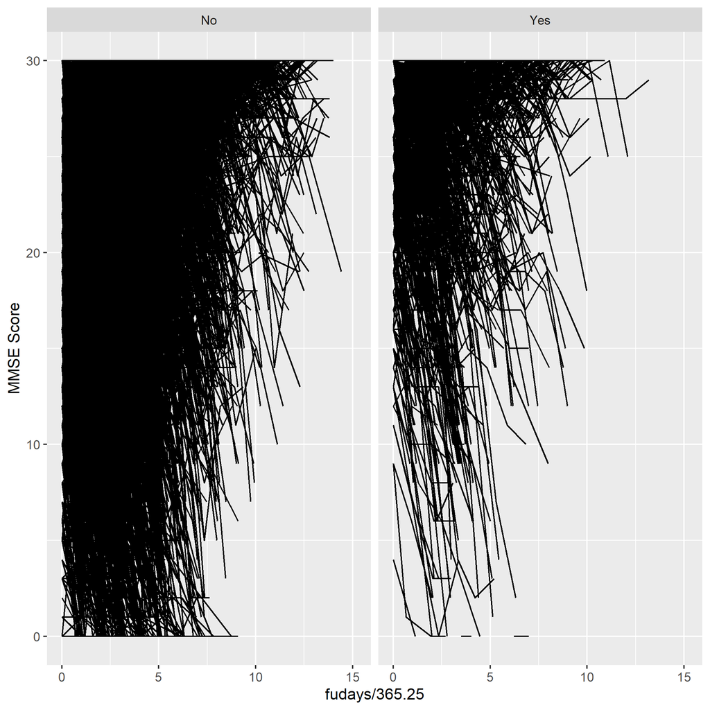

[figure not shown]

### 2.2.2 Cognition Stages

|  | 1 | 3 | 4 |
| --- | --- | --- | --- |
| 1 | 11.7 | 4.9 | 7.2 |
| 3 | 0.0 | 2.4 | 15.2 |
| 4 | 0.0 | 0.0 | 58.6 |

Among subjects with AF:

[output not shown]

Among subjects without AF:

[output not shown]